# Soal 4

Supaya data dapat dianalisis

1. Menelaah data untuk melihat potensi analisis yang bisa dilakukan dan bermanfaat
2. Load data ke r, jika ada masalah dalam load data, cek file dengan aplikasi microsoft excel
3. Menyesuaikan tipe data
4. cek nilai null di setiap kolom
5. membuang data null
6. cek statistik deskriptif nya
7. Melakukan visualisasi untuk mendasari analisis yang akan dilakukan
8. Mempersiapkan data sesuai hasil eksplorasi dengan melihat nilai statistik deskriptif dan visualisasi yang dibuat
9. Mempersiapkan data sesuai dengan ketentuan algoritma yang hendak digunakan
10. Membuat model dengan data yang sudah dipersiapkan
11. Menguji kemampuan model yang dibuat

Khusus untuk analisis yang akan digunakan dalam dunia nyata, ada step tambahan

12. Membuat model dapat digunakan untuk memprediksi data baru
13. Memonitor performa model dari waktu ke waktu
14. Jika terjadi data drifting hingga threshold metrics tidak baik lagi, maka melakukan pembuatan model baru

## Read Dataset

```r
#setwd("D:/Kuliah/Semester 1/Data Mining dan Business Intelligence/UTS/")
library(readxl)
df_raw = read_excel("D:/Kuliah/Semester 1/Data Mining dan Business Intelligence/UTS/DataCredit (1).xlsx")
```

## Inspect Dataset

```r
head(df_raw)
```

```
## # A tibble: 6 × 5
##   clientid income   age   loan default
##      <dbl>  <dbl> <dbl>  <dbl>   <dbl>
## 1        1 66156.  59.0 8107.        0
## 2        2 34415.  48.1 6565.        0
## 3        3 57317.  63.1 8021.        0
## 4        4 42710.  45.8 6104.        0
## 5        5 66953.  18.6 8770.        1
## 6        6 24904.  57.5   15.5       0
```

```r
lapply(df_raw,function(x) { length(which(is.na(x)))})
```

```
## $clientid
## [1] 0
##
## $income
## [1] 0
##
## $age
## [1] 3
##
## $loan
## [1] 0
##
## $default
## [1] 0
```

```r
df_clean = as.data.frame(na.omit(df_raw))
lapply(df_clean,function(x) { length(which(is.na(x)))})
```

```
## $clientid
## [1] 0
##
## $income
## [1] 0
##
## $age
## [1] 0
##
## $loan
## [1] 0
##
## $default
## [1] 0
```

```r
df_clean = df_clean[c(-1)]
```

```r
str(df_clean)
```

```
## 'data.frame':    1997 obs. of  4 variables:
##  $ income : num  66156 34415 57317 42710 66953 ...
##  $ age    : num  59 48.1 63.1 45.8 18.6 ...
##  $ loan   : num  8107 6565 8021 6104 8770 ...
##  $ default: num  0 0 0 0 1 0 0 1 0 0 ...
```

```r
summary(df_clean)
```

```
##      income           age              loan              default
##  Min.   :20014   Min.   :-52.42   Min.   :    1.378   Min.   :0.0000
##  1st Qu.:32805   1st Qu.: 28.99   1st Qu.: 1936.813   1st Qu.:0.0000
##  Median :45789   Median : 41.32   Median : 3977.287   Median :0.0000
##  Mean   :45334   Mean   : 40.81   Mean   : 4445.488   Mean   :0.1417
##  3rd Qu.:57788   3rd Qu.: 52.59   3rd Qu.: 6440.861   3rd Qu.:0.0000
##  Max.   :69996   Max.   : 63.97   Max.   :13766.051   Max.   :1.0000
```

From the summary statistic, there are several things that pick up interest 1. Age have negative value 2. Age value is in float format, maybe because its today-datebirth withoud rounding the value

```r
length(unique(df_clean$clientid))
```

```
## [1] 0
```

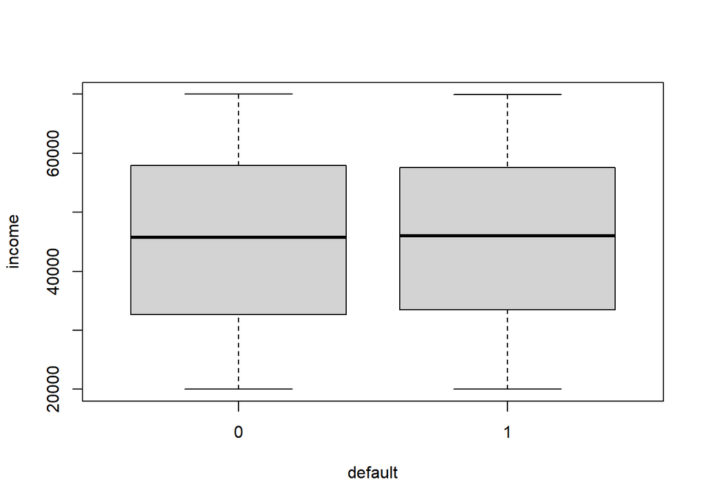

```r
boxplot(income~default, data=df_clean)
```

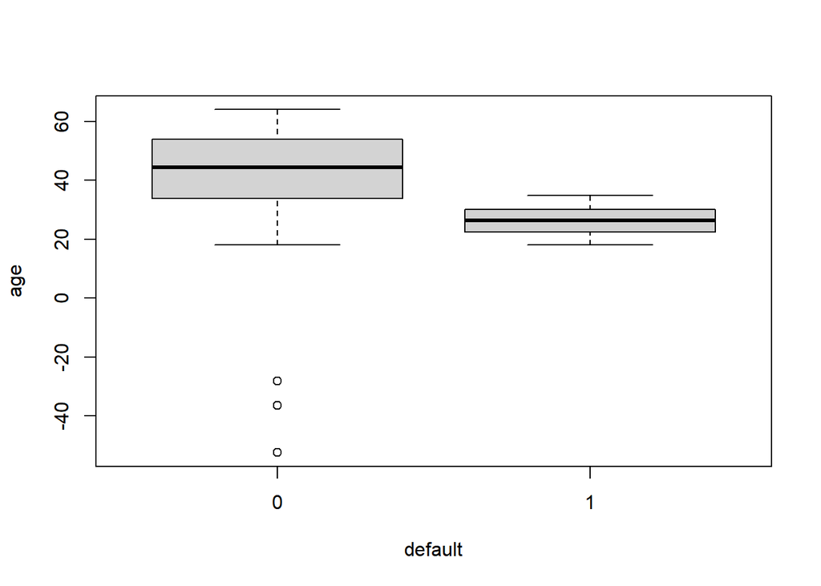

```r
boxplot(age~default, data=df_clean)
```

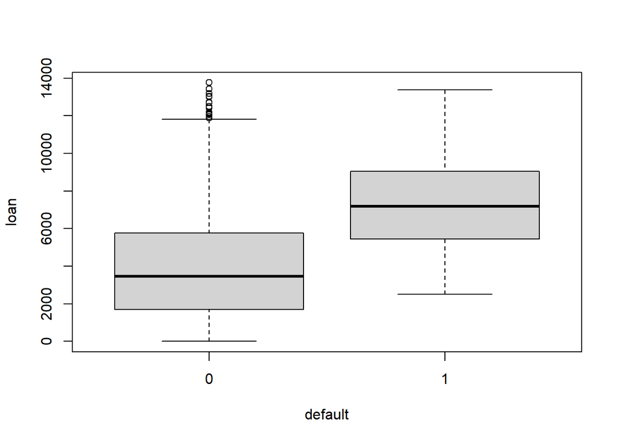

```r
boxplot(loan~default, data=df_clean)
```

From the boxplot above, there’s outlier in age and loan of default=0, so next thing to do is drop age that is outlier

## Data Preprocessing

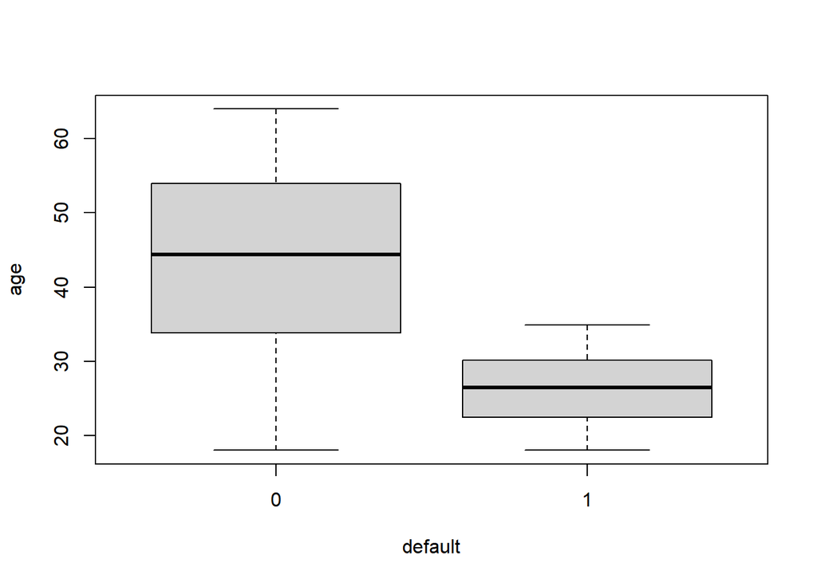

```r
df_out = subset(df_clean, df_clean$age>=0)
boxplot(age~default, data=df_out)
```

for the outlier in loan of default=0, let’s create histogram

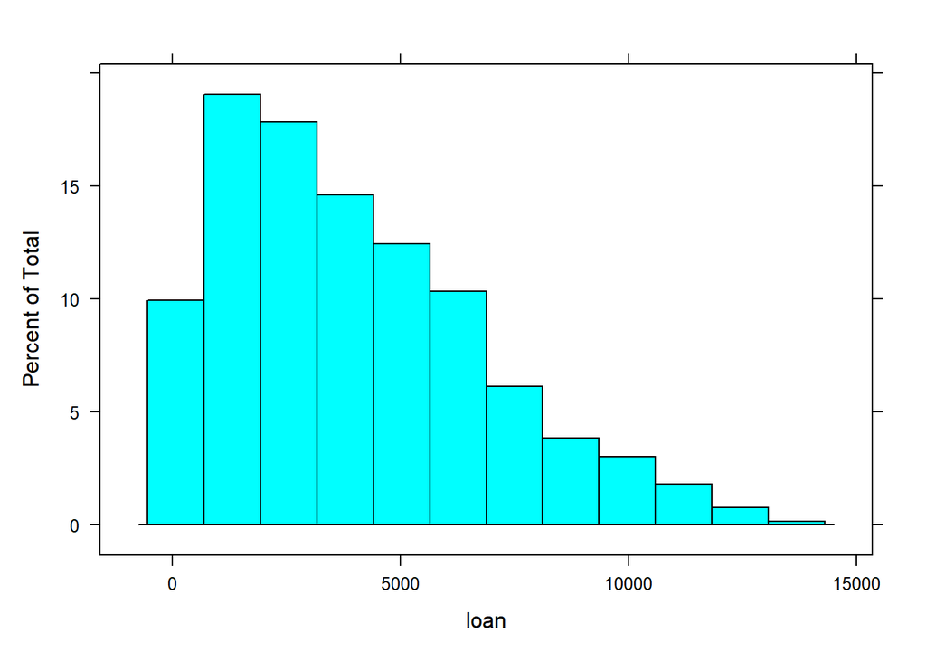

```r
library(lattice)
histogram(~loan, data=subset(df_out, df_out$default==0))
```

From the histogram, we knew that the outlier value is accounted for a small portion of the data, therefore it can be dropped

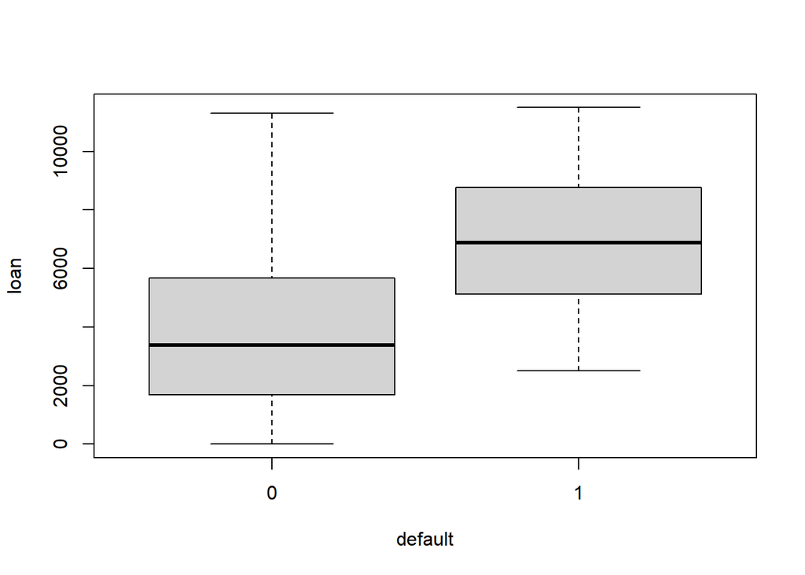

```r
df_out = subset(df_out, df_out$loan<=11500)
boxplot(loan~default, data=df_out)
```

After take out the outlier, we can see that roughtly, between default = 0 and default = 1, there are different in age and loan, but roughly the same for the the income. Next, we inspect the correlation within predictor variables

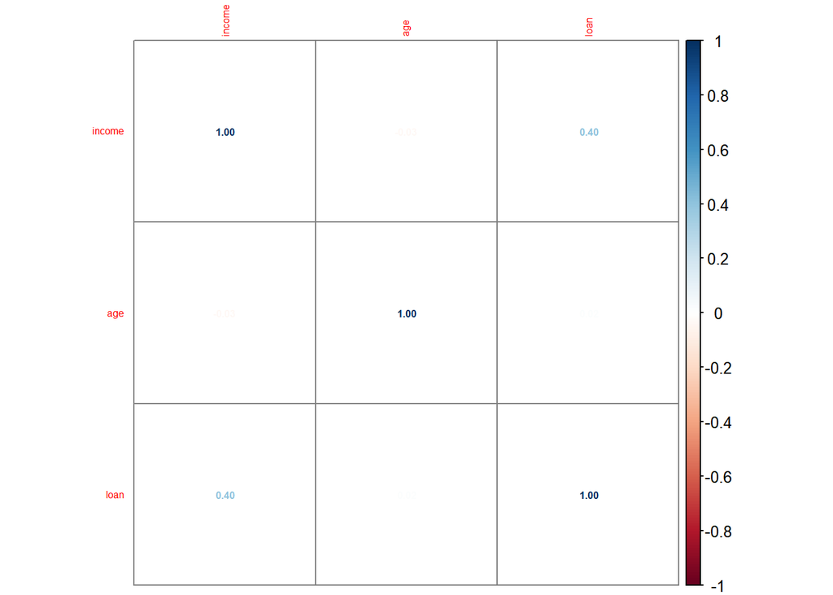

```r
#install.packages("corrplot")
library(psych)
library(corrplot)
#corPlot(cor(df_norm[(-1)]), cex=0.3, tl.cex=1, xlas=3)
corrplot(cor(df_out[(-4)], df_out[(-4)]),
         method = c("number"),
         #bg = "grey10",
         addgrid.col = "gray50",
         tl.cex=0.5,
         number.cex=0.5)
```

From the correlation plot, there is almost no correlations, but income and loan has quite moderate value, so lets incpect it with scatter plot

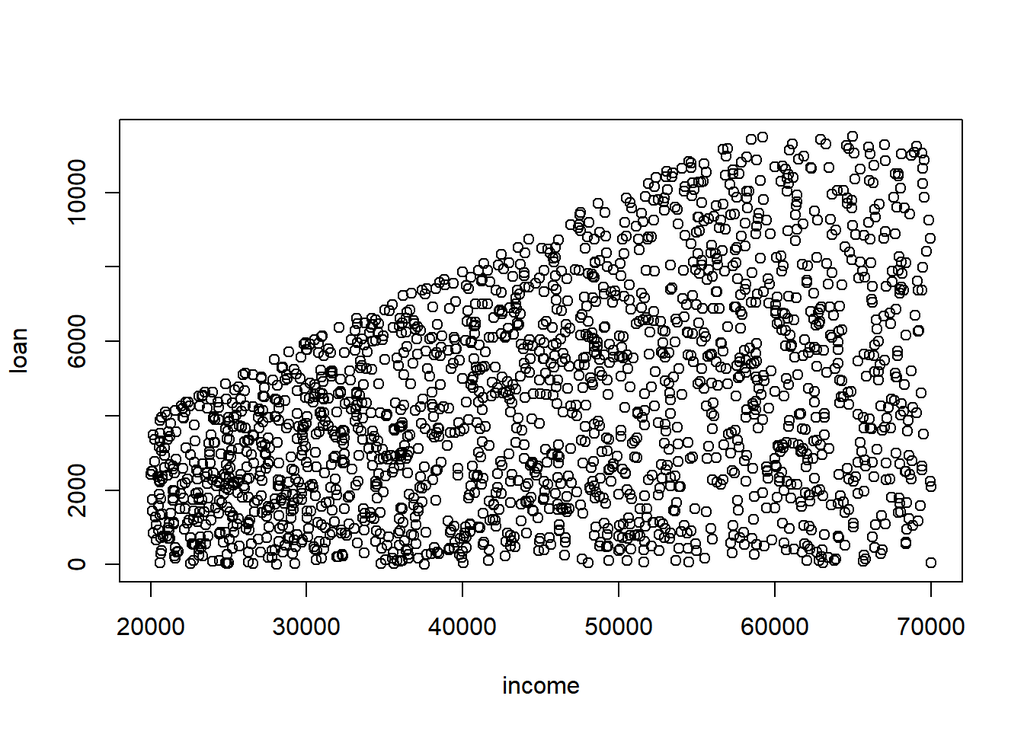

```r
plot(loan~income, data=df_out)
```

From the scatter plot, as we can see, there is heteroscedasticity and therefore, we can use these two variable to make prediction.

```r
#install.packages("conflicted")
library(conflicted)
conflict_prefer("apply", "base")
```

```
## [conflicted] Will prefer base::apply over any other package
```

```r
# Create Response Variable as DataFrame
df_target=as.data.frame(df_out[c(4)])
df_out = df_out[c(-4)]

# Norm Z function declaration
normalisasi=function(x){
  xm=colMeans(x)
  jb=dim(x)[1]
  xc=x-rep(xm,each=jb)
  sdx=apply(x,2,sd)
  xstd=xc/rep(sdx,each=jb)
  output=data.frame(xstd)
  #output=data.frame(xstd,x)
  return(output)
}


# Min-Max Norm function declaration
min_max_norm <- function(x) {
    (x - min(x)) / (max(x) - min(x))
  }

# Normalization
#df_norm = normalisasi(df_out)
df_norm = as.data.frame(lapply(df_out, min_max_norm))

# Outer Join Dataset
df_norm = data.frame(df_target,df_norm)

# Label encoding for response variable
df_norm$default = factor(df_norm$default, levels = c(0,1))
#df_norm
head(df_norm)
```

```
##   default     income       age        loan
## 1       0 0.92317590 0.8920917 0.705142270
## 2       0 0.28812165 0.6547079 0.571007965
## 3       0 0.74633429 0.9811888 0.697696977
## 4       0 0.45407166 0.6031975 0.530892376
## 5       1 0.93911717 0.0115241 0.762872103
## 6       0 0.09782828 0.8584349 0.001228514
```

```r
str(df_norm)
```

```
## 'data.frame':    1956 obs. of  4 variables:
##  $ default: Factor w/ 2 levels "0","1": 1 1 1 1 2 1 1 2 1 1 ...
##  $ income : num  0.923 0.288 0.746 0.454 0.939 ...
##  $ age    : num  0.8921 0.6547 0.9812 0.6032 0.0115 ...
##  $ loan   : num  0.705 0.571 0.698 0.531 0.763 ...
```

```r
#unique(df_norm$Attrition)
```

Next, create train and test dataset

### Create Class Balanced Train and test Dataset

```r
#install.packages("caret")
library(caret)
'%ni%' = Negate('%in%')
options(scipen=999)

set.seed(100)
str(df_norm)
```

```
## 'data.frame':    1956 obs. of  4 variables:
##  $ default: Factor w/ 2 levels "0","1": 1 1 1 1 2 1 1 2 1 1 ...
##  $ income : num  0.923 0.288 0.746 0.454 0.939 ...
##  $ age    : num  0.8921 0.6547 0.9812 0.6032 0.0115 ...
##  $ loan   : num  0.705 0.571 0.698 0.531 0.763 ...
```

```r
df_train_test= df_norm
```

```r
trainDataIndex= createDataPartition(df_train_test$default, p=0.8, list = F)

trainData = df_train_test[trainDataIndex,]
testData = df_train_test[-trainDataIndex,]

# Down sample
set.seed(100)
down_train=downSample(x=trainData[, colnames(trainData)%ni%"default"], y=trainData$default)
#table(down_train$Class)

# Up Sample
set.seed(100)
up_train = upSample(x = trainData[, colnames(trainData)%ni%"default"], y = trainData$default)
table(up_train$Class)
```

```
##
##    0    1
## 1353 1353
```

### Create Logistic Regression Model

```r
logitmod = glm(Class~., family = "binomial", data=up_train)
summary(logitmod)
```

```
##
## Call:
## glm(formula = Class ~ ., family = "binomial", data = up_train)
##
## Deviance Residuals:
##     Min       1Q   Median       3Q      Max
## -3.2052  -0.0260   0.0019   0.1818   2.0435
##
## Coefficients:
##             Estimate Std. Error z value            Pr(>|z|)
## (Intercept)   0.1202     0.2568   0.468                0.64
## income      -13.7551     0.8271 -16.630 <0.0000000000000002 ***
## age         -17.5137     0.9498 -18.439 <0.0000000000000002 ***
## loan         23.2203     1.2837  18.089 <0.0000000000000002 ***
## ---
## Signif. codes:  0 '***' 0.001 '**' 0.01 '*' 0.05 '.' 0.1 ' ' 1
##
## (Dispersion parameter for binomial family taken to be 1)
##
##     Null deviance: 3751.31  on 2705  degrees of freedom
## Residual deviance:  768.35  on 2702  degrees of freedom
## AIC: 776.35
##
## Number of Fisher Scoring iterations: 8
```

### Model Validation using Accuracy Metrics

```r
pred <- predict(logitmod, testData, type = "response")

y_pred_num = ifelse(pred>0.5,1,0)
y_pred = factor(y_pred_num, levels=c(0,1))
y_act = testData$default

mean(y_pred==y_act)
```

```
## [1] 0.9360614
```